# Part_I_exploration_template slides

## Ford GoBike Program

## Data Analysis

## Introduction

This datast contains 183,412 records of bike trips on the San Francisco city in California.  
Was launched on August 2013 and has 4618 bikes in 329 stations. It contains information of just 1 month, which is February 2019. The pricing information is not in the dataset but was pulled from wikipedia, this can give context to understand better the data.

**Fares:**  
Single rides start at 3 usd.  
Day passes are: 10 usd.  
Month membership is: 25 usd.  
Year membership is: 159 usd.

**Times:**  
Single ride or day pass 30 min (1800 seconds)  
Full price members 45 min. (2700 seconds)  
Each additional 15 min cost 3 usd extra (2 usd for members).

### Structure of your dataset

The dataset after cleaning has 2 tables or dataframes.

| Column Name | Description |
| --- | --- |
| **duration_sec** | Bike ride duration in seconds. |
| **start_time** | Time at the ride started. |
| **end_time** | Time at the ride ended. |
| **start_station_id** | Id of the station where the ride started. |
| **end_station_id** | Id of the station where the ride ended. |
| **bike_id** | Id of the bike used for the trip. |
| **user_type** | Can be Customer or subscriber |
| **member_birth_year** | Id of the station where the ride ended. |
| **member_gender** | Can be Male, Female or Other, also can be blank. |
| **bike_share_for_all_trip** | Id of the station where the ride ended . |

| Column name | Description |
| --- | --- |
| id | Integer representing a station. |
| name | Name of the station, street and number or streets crossing. |
| latitude | Float representing latitude coordinate of the station. |
| longitude | Float representing longitude coordinate of the station. |

### Main features of interest in the dataset

1. Who uses the service more.
2. When are rides more active.
3. Where do the bikes go more often.
4. How much time do the rides last.

### Questions about tIme.

1. How is the ride time distributed?
2. Do users stick to the normal ride time or they pay extra?

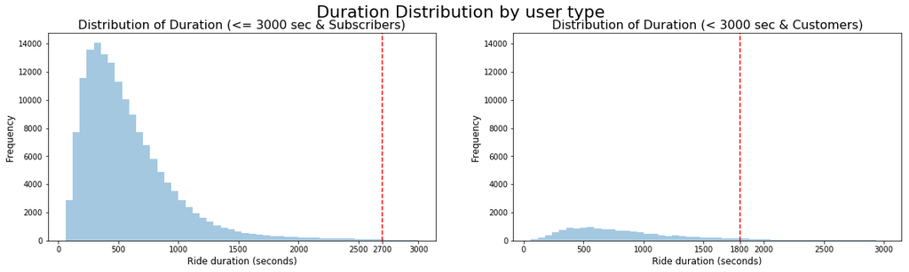

### Answer

1. We can see that the ride duration time is highly skewed to the right.
2. We can see on the charts that for subscribers they almost never exceed the time, less than 1%. And for Customers group sligthly more than 11%, this and the volume of rides suggest that this group are visitors / tourists, not regular users.
3. Rides last on average 9.6min for 99% of Subscribers and 13min for 88% of Customers.

[output not shown]

### Question

Among the users who uses the service de most? male, females?.

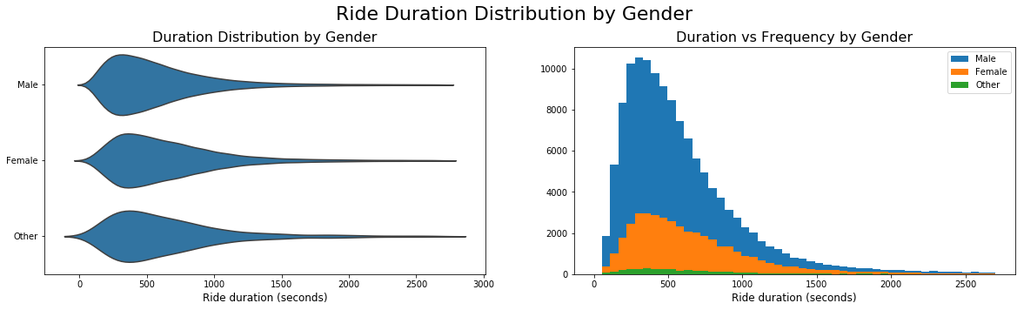

### Answer

We can see the beahvior or type of usage is about the same looking at the violin plot, but on the histogram we can see that **the vast majority of users is male**.

### Questions

How do ages are related to BikeGo usage?

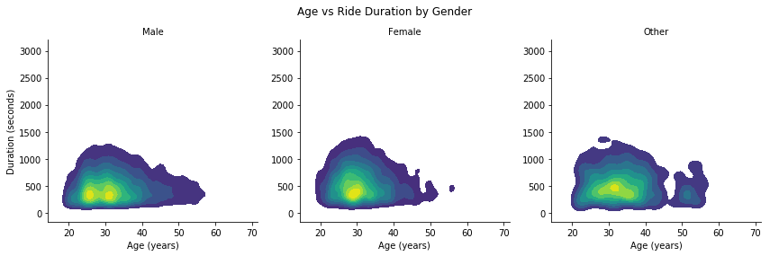

### Answer

Most of the users are around 30 years old at the time the data was sampled. Also the data is concentrated below 25min ride duration.

### Question

What are the days with more rides?

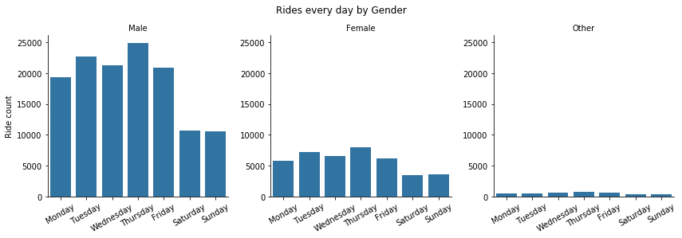

### Answer

The number of rides is more elevated on weekdays.

### Question

Does the trip time changes over the week?

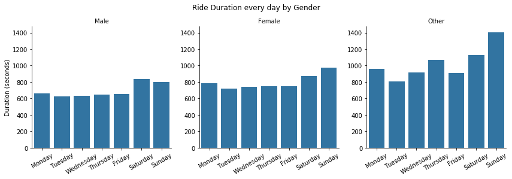

### Answer

The trip duration on average lasts longer on weekends.

### Question

What are the peak hours when the bike service is being used?

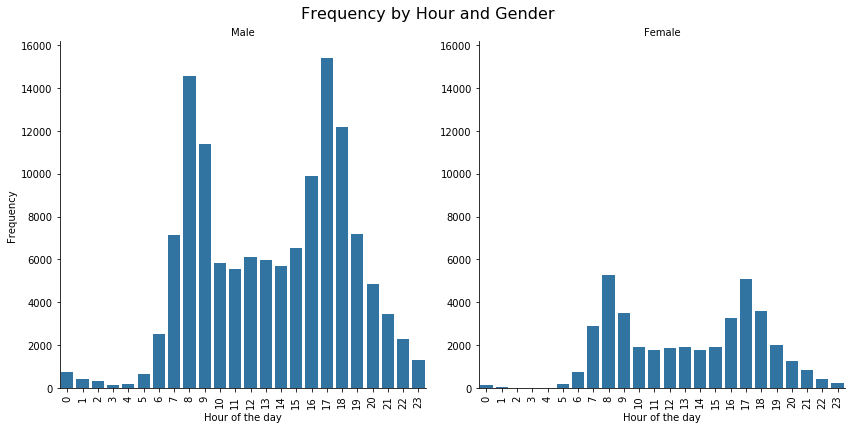

### Answer

There is a bimodal distribution, since this is a count and previously we saw that weekdays contain the highest count of rides this charts suggest that work start and end are the peak hours. (8am and 5pm).

## Conclusions

The Ford GoBike generating sales for 0.5M usd and helping the city to lower traffic, contamination, helping people save on gas, improving their health is something that other cities should be modeling.  
With 180k+ rides a month this is without a doubt a widely adopted system.  
For the analysis we can conclude that the users are mainly young men using the bikes for 10min trips on weekdays.